# Le marché du travail américain résistera-t-il au resserrement monétaire ?

Auteur·rice

Christophe Blot

En mars 2022, la banque centrale américaine amorçait un resserrement monétaire pour faire face à l’augmentation rapide de l’inflation aux Etats-Unis. Depuis, le taux cible de la politique monétaire a été augmenté à chaque réunion du FOMC ce qui le porte désormais à 5 %. L’objectif de ces décisions est de ramener l’inflation vers la cible de 2 % visée par la Réserve fédérale. Après avoir atteint un pic à l’été 2022, l’inflation a baissé en lien avec le repli des prix de l’énergie. Parallèlement, l’activité économique a jusqu’ici résisté et le taux de chômage reste stable malgré le durcissement des conditions monétaires et financières. L’inflation va-t-elle continuer de baisser et surtout, peut-elle converger vers la cible sans hausse du chômage ?

## Une inflation maîtrisée ?

Tout au long de l’année 2021, la Réserve fédérale s’était montrée prudente, considérant que l’augmentation des prix serait transitoire. Ce n’est qu’à partir du mois de mars 2022 qu’elle a amorcé le resserrement monétaire un peu plus d’un an après que l’inflation ne commence à dépasser la cible de 2 % et alors qu’elle atteignait 6,8 %[^1]. La hausse des prix s’est effectivement avérée plus durable que ce qu’avaient anticipé les membres du FOMC (*Federal Open Market Committee*) et s’est propagée à l’ensemble des composantes de l’indice. Enfin, la banque centrale craignait également un risque de déconnexion des anticipations d’inflation qui aurait entretenu une spirale inflationniste. Une fois enclenché, le mouvement de hausses de taux a été rapide puisqu’en un an le taux cible pour les fonds fédéraux est passé de 0,25 % à 5 %, soit un rythme de durcissement bien plus rapide que ceux observés lors des cycles précédents (Figure 1) et en particulier celui de 2015 où la Réserve fédérale n’avait remonté les taux que deux fois en un an et seulement de 0,25 point à chaque fois.

Figure 1: Le resserrement monétaire de 2022 comparé aux précédents

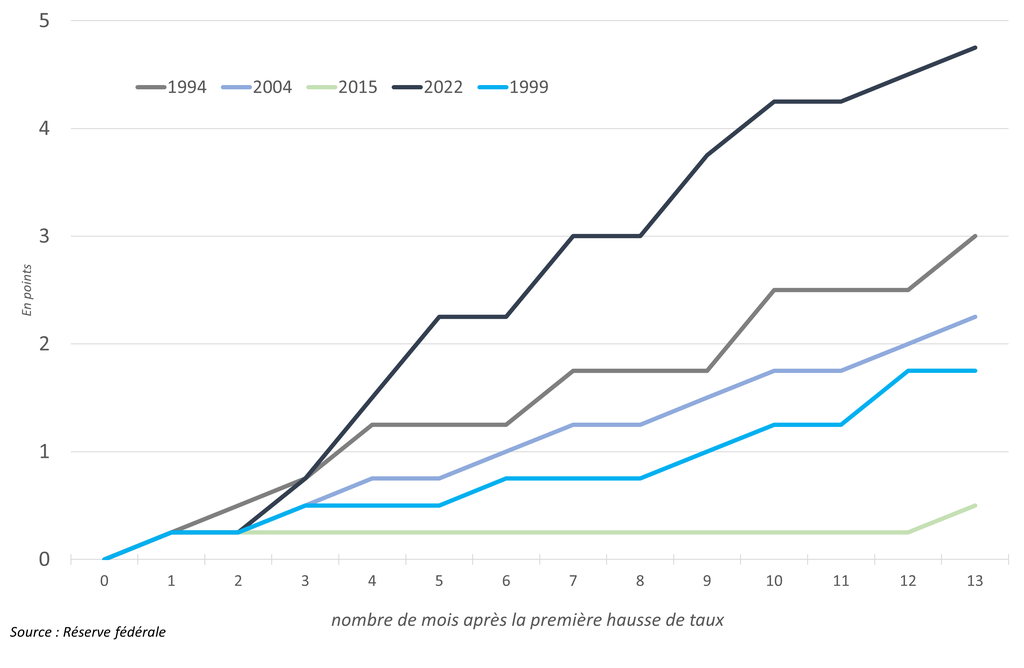

Quelques mois à peine après le début du resserrement, l’inflation a atteint un pic. De 7 % en glissement annuel observé en juin 2022, elle a progressivement reflué s’élevant à 5 % en février 2023. Pour autant, cette baisse n’est pas à mettre au crédit de la Réserve fédérale puisqu’elle résulte principalement de l’évolution de la composante énergie, elle-même directement liée à la baisse des prix du pétrole et, dans une moindre mesure du prix du gaz américain[^2]. En février 2023, la composante énergie du déflateur de la consommation baissait de 0,9 % sur un an alors que les prix de l’énergie avaient augmenté de 60,8 % en juin 2022. Même si la composante alimentaire reste dynamique, sa progression marque le pas.

Au-delà de la composante énergie, la baisse de l’inflation peut-elle se prolonger ? Sous l’hypothèse d’une stabilité du prix du pétrole et du prix du gaz, la contribution des prix de l’énergie poussera effectivement encore l’inflation américaine à la baisse dans les prochains mois. La fin de l’épisode inflationniste dépendra cependant principalement de l’évolution de l’inflation sous-jacente, qui intègre certes un effet de diffusion des prix de l’énergie mais dont la dynamique dépend surtout de facteurs d’offre et de demande.